# Investigating sQTL analysis results of interest: a deeper look

From this notebook we've got some examples, particularly for the 4 QTL case where the smallest p-value has small PIP, and it seems to be driven by adjunct signal clusters. We want to see if SuSiE's results makes more sense, specifically if it falls in splice sites.

```python
%cd /project/compbio/jointLCLs/results/SuSiE/fastqtl_qqnorm_ASintron_RNAseqGeuvadis_YangVCF_100Kb
```

```
/project/compbio/jointLCLs/results/SuSiE/fastqtl_qqnorm_ASintron_RNAseqGeuvadis_YangVCF_100Kb
```

## 4 QTL case

%preview SuSiE_CS_4/AS_chr12_27542229_27543032_clu_562.png

> SuSiE_CS_4/AS_chr12_27542229_27543032_clu_562.png (180.2 KiB):

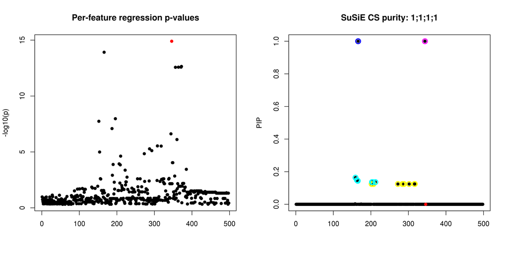

```python
%preview SuSiE_CS_4/AS_chr12_27542229_27543032_clu_562.png
```

### Load data and get positions of interest

Load SuSiE results

```python
dat = readRDS('SuSiE_CS_4/AS_chr12_27542229_27543032_clu_562.rds')
```

```python
names(dat)
```

1. 'input'

2. 'idx'

3. 'fitted'

4. 'sets'

5. 'pip'

Load input data

```python
print(dat$input)
input = readRDS(dat$input)
```

```
[1] "/project/compbio/jointLCLs/results/SuSiE/fastqtl_qqnorm_ASintron_RNAseqGeuvadis_YangVCF_100Kb/chr12/chr12_27542229_27543041.rds"
```

```python
sapply(1:length(input), function(i) input[[i]]$uname)
```

1. 'AS_chr12_27542229_27543029_clu_562'

2. 'AS_chr12_27542229_27543032_clu_562'

3. 'AS_chr12_27542229_27543041_clu_562'

So it is the 2nd data-set in the input intron cluster that we are interested in.

```python
input = input[[2]]
input$uname
```

'AS_chr12_27542229_27543032_clu_562'

Now let's identify the SNP having the largest z-score,

```python
which.max(abs(input$z_score))
```

**rs55880072_chr12_27612517_A_C:** 346

and the ones in SuSiE CS:

```python
dat$sets$cs
```

**$L2**

166

**$L4**

344

**$L5**

1. 202

2. 207

3. 272

4. 284

5. 288

6. 302

7. 316

8. 317

**$L3**

1. 159

2. 163

3. 165

4. 203

5. 204

6. 205

7. 212

```python
interested = as.vector(unlist(dat$sets$cs))
interested
```

1. 166

2. 344

3. 202

4. 207

5. 272

6. 284

7. 288

8. 302

9. 316

10. 317

11. 159

12. 163

13. 165

14. 203

15. 204

16. 205

17. 212

```python
names(input$z_score)[interested]
```

1. 'rs76733902_chr12_27542629_T_A'

2. 'rs11049018_chr12_27612107_A_G'

3. 'rs149761989_chr12_27559962_A_G'

4. 'rs145210967_chr12_27561492_A_G'

5. 'rs10842915_chr12_27591756_T_C'

6. 'rs12306687_chr12_27597822_G_A'

7. 'rs150330389_chr12_27598897_C_T'

8. 'rs11049014_chr12_27602813_G_A'

9. 'rs113091867_chr12_27606290_G_A'

10. 'rs112473472_chr12_27606682_G_A'

11. 'rs76926063_chr12_27536489_C_G'

12. 'rs77927877_chr12_27540821_T_C'

13. 'rs113228767_chr12_27542493_A_G'

14. 'rs147878198_chr12_27560041_C_G'

15. 'rs145679811_chr12_27560707_G_T'

16. 'rs147715803_chr12_27561169_A_C'

17. 'rs111384326_chr12_27564097_A_G'

### UCSC query

%preview ~/tmp/arntl2.png

> /home/gaow/tmp/arntl2.png (31.7 KiB):

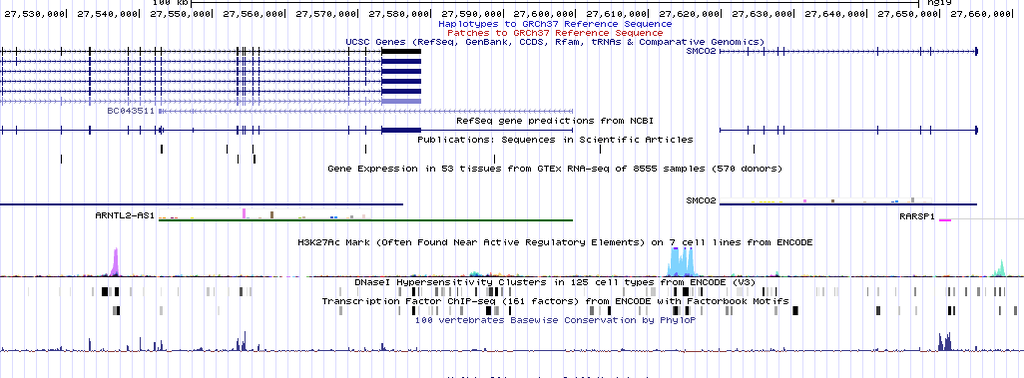

```python
%preview ~/tmp/arntl2.png
```

Hard to argue about anything interesting.

## 5 QTL case

%preview SuSiE_CS_5/AS_chr12_27542229_27543041_clu_562.png

> SuSiE_CS_5/AS_chr12_27542229_27543041_clu_562.png (196.3 KiB):

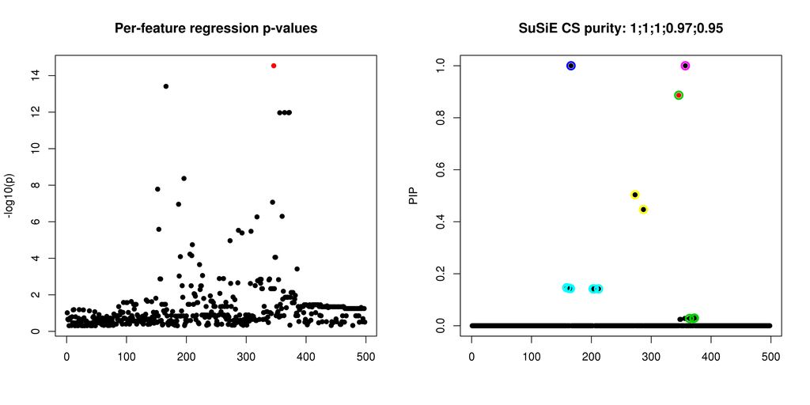

```python
%preview SuSiE_CS_5/AS_chr12_27542229_27543041_clu_562.png
```

### Load data and get positions of interest

```python
dat = readRDS('SuSiE_CS_5/AS_chr12_27542229_27543041_clu_562.rds')
input = readRDS(dat$input)
sapply(1:length(input), function(i) input[[i]]$uname)
```

1. 'AS_chr12_27542229_27543029_clu_562'

2. 'AS_chr12_27542229_27543032_clu_562'

3. 'AS_chr12_27542229_27543041_clu_562'

```python
input = input[[3]]
which.max(abs(input$z_score))
```

**rs55880072_chr12_27612517_A_C:** 346

```python
dat$sets$cs
```

**$L2**

166

**$L4**

357

**$L3**

1. 159

2. 163

3. 165

4. 203

5. 204

6. 205

7. 212

**$L5**

1. 273

2. 287

**$L1**

1. 346

2. 364

3. 371

4. 372

```python
interested = as.vector(unlist(dat$sets$cs))
interested
```

1. 166

2. 357

3. 159

4. 163

5. 165

6. 203

7. 204

8. 205

9. 212

10. 273

11. 287

12. 346

13. 364

14. 371

15. 372

```python
names(input$z_score)[interested]
```

1. 'rs76733902_chr12_27542629_T_A'

2. 'rs67786386_chr12_27616181_C_A'

3. 'rs76926063_chr12_27536489_C_G'

4. 'rs77927877_chr12_27540821_T_C'

5. 'rs113228767_chr12_27542493_A_G'

6. 'rs147878198_chr12_27560041_C_G'

7. 'rs145679811_chr12_27560707_G_T'

8. 'rs147715803_chr12_27561169_A_C'

9. 'rs111384326_chr12_27564097_A_G'

10. 'rs73298732_chr12_27592252_G_A'

11. 'rs113424189_chr12_27598865_C_T'

12. 'rs55880072_chr12_27612517_A_C'

13. 'rs73082065_chr12_27619827_A_G'

14. 'rs10506020_chr12_27621942_C_T'

15. 'rs10506021_chr12_27622549_C_G'

We focus on `rs67786386_chr12_27616181_C_A` vs `rs55880072_chr12_27612517_A_C` (same as before). We query `chr12:27612517-27616381`

### USCS query

%preview ~/tmp/arntl2_right.png

> /home/gaow/tmp/arntl2_right.png (26.7 KiB):

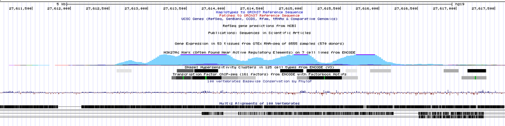

```python
%preview ~/tmp/arntl2_right.png
```

It does fall into DNase I cluster, but nothing interesting beyond this point.

```python
[global]
parameter: fn=path()

[default]
input: fn
R: expand = True
	dat = readRDS({_input:r})
	input = readRDS(dat$input)
	idx = which(sapply(1:length(input), function(i) input[[i]]$uname) == {_input:bnr})
	input = input[[idx]]
	znames = names(input$z_score)
    zidx = which.max(abs(input$z_score))
    print(zidx)
	print(znames[zidx])
	interested = as.vector(unlist(dat$sets$cs))
	print(dat$sets$cs)
	print(znames[interested])
```

## 2 QTL case

%preview SuSiE_CS_2/AS_chr19_50837358_50838086_clu_8171.png

> SuSiE_CS_2/AS_chr19_50837358_50838086_clu_8171.png (202.1 KiB):

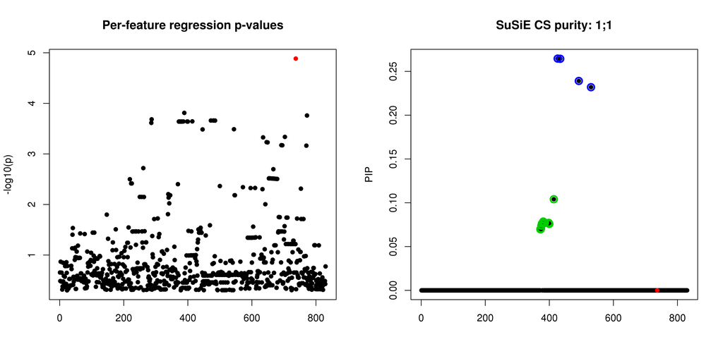

```python
%preview SuSiE_CS_2/AS_chr19_50837358_50838086_clu_8171.png
```

```python
%sosrun --fn SuSiE_CS_2/AS_chr19_50837358_50838086_clu_8171.rds
```

```
rs3219404_chr19_50911461_G_A
                         737
[1] "rs3219404_chr19_50911461_G_A"
$L2
[1] 426 434 492 530

$L1
 [1] 372 373 374 375 376 377 380 381 382 386 398 400 414

 [1] "rs10408648_chr19_50856940_G_A"  "rs11881647_chr19_50857469_A_G"
 [3] "rs115115058_chr19_50874717_G_A" "rs2695120_chr19_50880536_T_C"
 [5] "rs140533621_chr19_50844210_C_T" "rs144378176_chr19_50844211_A_G"
 [7] "rs147907106_chr19_50844214_C_T" "rs613694_chr19_50844219_C_G"
 [9] "rs614567_chr19_50844397_C_A"    "rs607307_chr19_50845021_G_A"
[11] "rs137953380_chr19_50845812_C_A" "rs591161_chr19_50846281_A_G"
[13] "rs590653_chr19_50846431_A_G"    "rs2546567_chr19_50848093_G_A"
[15] "rs627400_chr19_50850761_A_G"    "rs625672_chr19_50851155_C_T"
[17] "rs679288_chr19_50854158_C_T"
```

INFO: Workflow default (ID=0d184be397c60cb8) is executed successfully with 1 completed step.

%preview SuSiE_CS_2/AS_chr19_54704756_54705028_clu_8215.png

> SuSiE_CS_2/AS_chr19_54704756_54705028_clu_8215.png (174.2 KiB):

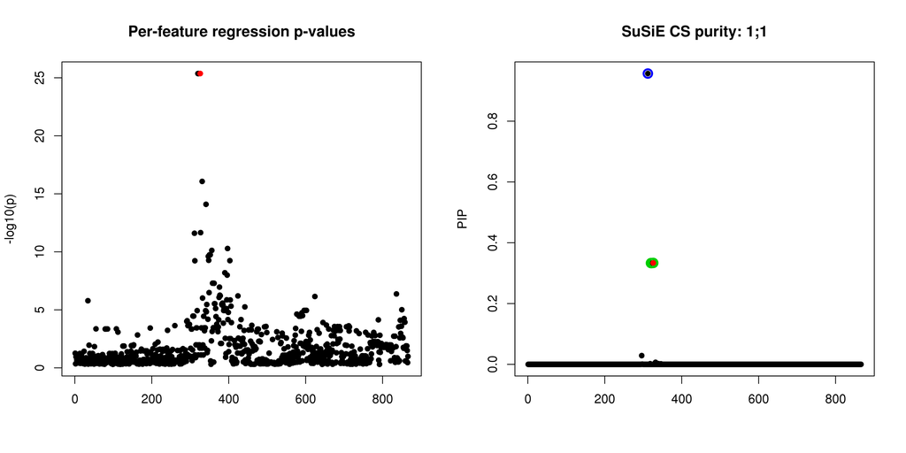

```python
%preview SuSiE_CS_2/AS_chr19_54704756_54705028_clu_8215.png
```

```python
%sosrun --fn SuSiE_CS_2/AS_chr19_54704756_54705028_clu_8215.rds
```

```
rs3852890_chr19_54709944_G_A
                         326
[1] "rs3852890_chr19_54709944_G_A"
$L2
[1] 312

$L1
[1] 320 322 326

[1] "rs60811961_chr19_54704775_C_G" "rs3852889_chr19_54708430_A_G"
[3] "rs10424181_chr19_54709277_C_A" "rs3852890_chr19_54709944_G_A"
```

INFO: Workflow default (ID=8828483c669a7f80) is executed successfully with 1 completed step.

%preview ~/tmp/rps9.png

> /home/gaow/tmp/rps9.png (42.6 KiB):

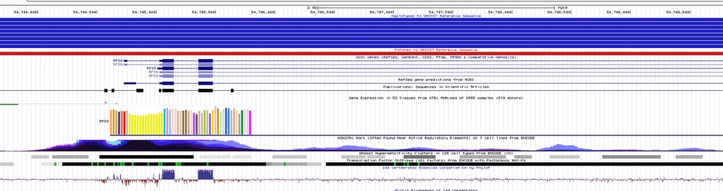

```python
%preview ~/tmp/rps9.png
```

SuSiE signal falls in the "Layered H3K27AC" peak.

%preview SuSiE_CS_2/AS_chr20_20007563_20013746_clu_9197.png

> SuSiE_CS_2/AS_chr20_20007563_20013746_clu_9197.png (189.0 KiB):

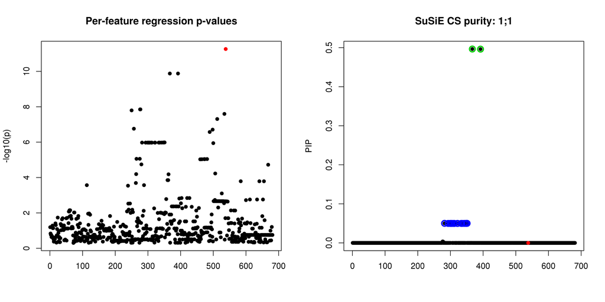

```python
%preview SuSiE_CS_2/AS_chr20_20007563_20013746_clu_9197.png
```

%preview SuSiE_CS_2/AS_chr20_37055833_37059684_clu_9365.png

> SuSiE_CS_2/AS_chr20_37055833_37059684_clu_9365.png (171.0 KiB):

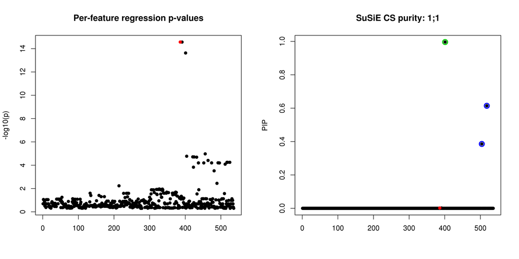

```python
%preview SuSiE_CS_2/AS_chr20_37055833_37059684_clu_9365.png
```

```python
%sosrun --fn SuSiE_CS_2/AS_chr20_37055833_37059684_clu_9365.rds
```

```
rs62203382_chr20_37071007_A_G
                          386
[1] "rs62203382_chr20_37071007_A_G"
$L1
[1] 401

$L2
[1] 504 518

[1] "rs73098016_chr20_37083100_T_A"  "rs59033379_chr20_37133858_G_A"
[3] "rs113883801_chr20_37143769_C_T"
```

INFO: Workflow default (ID=c5661f95d9c07b4a) is executed successfully with 1 completed step.

%preview SuSiE_CS_2/AS_chr20_57570814_57572658_clu_9568.png

> SuSiE_CS_2/AS_chr20_57570814_57572658_clu_9568.png (183.6 KiB):

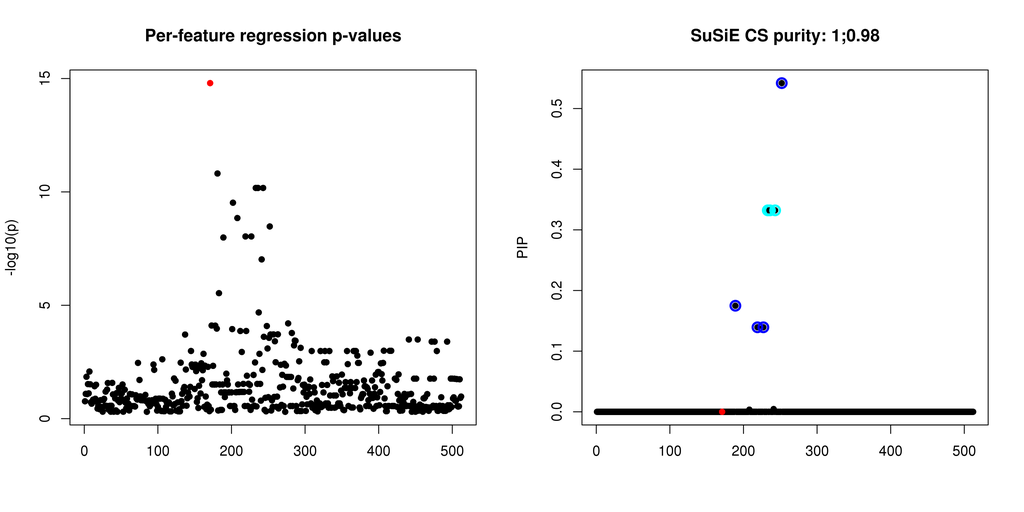

```python
%preview SuSiE_CS_2/AS_chr20_57570814_57572658_clu_9568.png
```

```python
%sosrun --fn SuSiE_CS_2/AS_chr20_57570814_57572658_clu_9568.rds
```

```
rs151362_chr20_57554311_C_A
                        171
[1] "rs151362_chr20_57554311_C_A"
$L3
[1] 233 236 243

$L2
[1] 189 219 227 252

[1] "rs2295357_chr20_57572839_G_T"   "rs139145965_chr20_57573596_C_T"
[3] "rs6070690_chr20_57574816_G_C"   "rs163779_chr20_57558274_T_C"
[5] "rs184673_chr20_57567543_A_G"    "rs13720_chr20_57570568_G_A"
[7] "rs191490_chr20_57576180_A_G"
```

INFO: Workflow default (ID=622a58859ee229ac) is executed successfully with 1 completed step.

%preview ~/tmp/ctsz.png

> /home/gaow/tmp/ctsz.png (56.1 KiB):

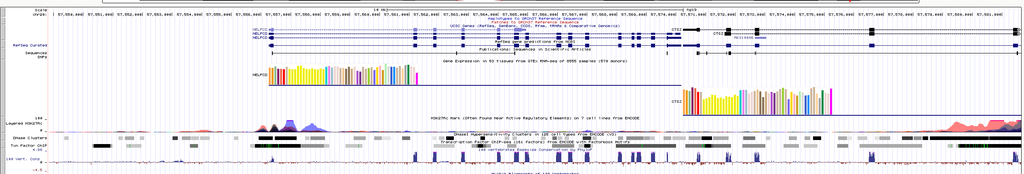

```python
%preview ~/tmp/ctsz.png
```

%preview ~/tmp/ak310046.png

> /home/gaow/tmp/ak310046.png (34.7 KiB):

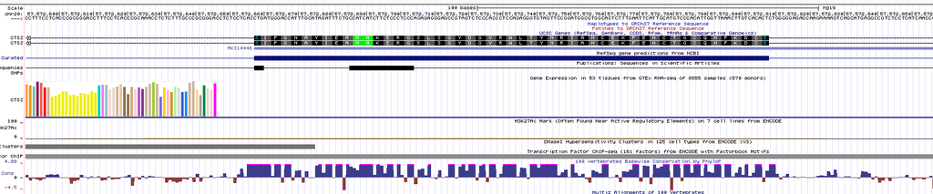

```python
%preview ~/tmp/ak310046.png
```

%preview SuSiE_CS_2/AS_chr22_30822832_30823227_clu_8715.png

> SuSiE_CS_2/AS_chr22_30822832_30823227_clu_8715.png (224.4 KiB):

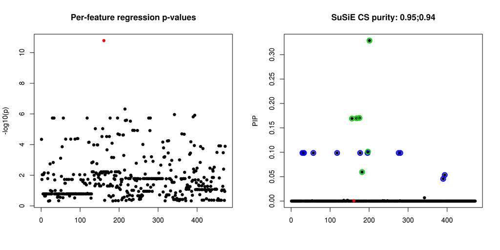

```python
%preview SuSiE_CS_2/AS_chr22_30822832_30823227_clu_8715.png
```

```python
%sosrun --fn SuSiE_CS_2/AS_chr22_30822832_30823227_clu_8715.rds
```

```
rs7292432_chr22_30796835_C_G
                         161
[1] "rs7292432_chr22_30796835_C_G"
$L2
 [1]  29  30  33  57 118 177 196 276 280 390 394

$L1
[1] 156 168 175 182 197 201

 [1] "rs75265757_chr22_30739174_G_A"  "rs114214629_chr22_30740914_C_G"
 [3] "rs116485157_chr22_30742894_A_G" "rs114429377_chr22_30753931_G_A"
 [5] "rs114302396_chr22_30775694_G_A" "rs116438221_chr22_30808588_G_A"
 [7] "rs78474653_chr22_30823133_G_A"  "rs116255130_chr22_30854639_G_A"
 [9] "rs78467477_chr22_30855806_C_T"  "rs11702947_chr22_30899264_T_G"
[11] "rs11704977_chr22_30900128_C_T"  "rs2412985_chr22_30792505_C_T"
[13] "rs4820845_chr22_30800338_T_G"   "rs2299824_chr22_30807524_T_C"
[15] "rs4820011_chr22_30810954_A_C"   "rs5753130_chr22_30823196_T_C"
[17] "rs1860215_chr22_30826800_G_A"
```

INFO: Workflow default (ID=d782cd38111eb59e) is executed successfully with 1 completed step.

30823133 and 30823196 both suggests one exon, in two different CS. There are also a number of other seemly interesting hits.

%preview ~/tmp/22-1.png

> /home/gaow/tmp/22-1.png (9.9 KiB):

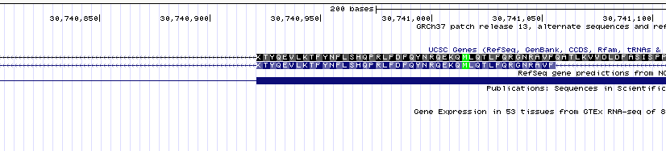

```python
%preview ~/tmp/22-1.png
```

%preview ~/tmp/22-2.png

> /home/gaow/tmp/22-2.png (10.9 KiB):

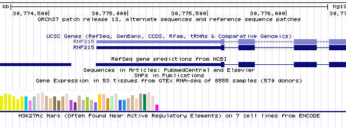

```python
%preview ~/tmp/22-2.png
```

%preview ~/tmp/22-3.png

> /home/gaow/tmp/22-3.png (16.3 KiB):

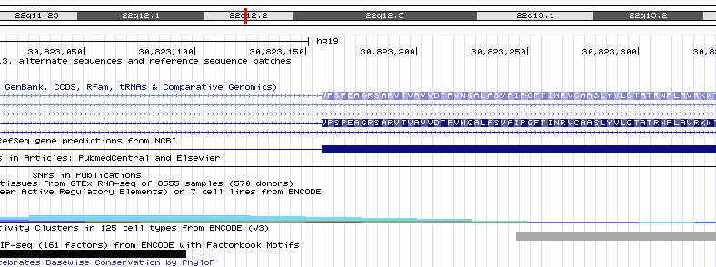

```python
%preview ~/tmp/22-3.png
```

%preview ~/tmp/22-4.png

> /home/gaow/tmp/22-4.png (18.4 KiB):

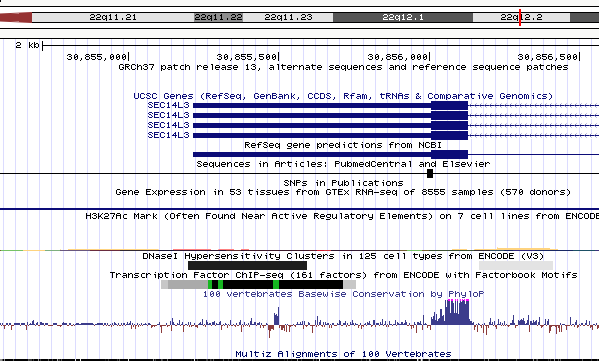

```python
%preview ~/tmp/22-4.png
```